# Week 5 Lab

# Can you paint with all the colors of the wind?

Welcome to data visualization! This is honestly one of my favorite weeks; I sincerly hope this isn’t you by the end of it!

[figure not shown]

```r
knitr::include_graphics("https://i.pinimg.com/originals/06/d2/3a/06d23a7d90baa72cffb29dad5c8cd122.jpg")
```

(Honestly, I actually just wanted an excuse to put in a Korra meme and it was the most applicable I could find.)

The data for this week’s lab comes from the `anesr` package as well as the course GitHub page.

## Challenge 1: A 🌹 by any other name.

The following image is constructed using the 2016 data from the `anesr` package. For the next challenge, I would like you to replicate this graph—but make it better. By “better,” I mean I’d like for you to write an informative:

- Title
- Subtitle
- X axis tick labels
- Y axis tick labels
- X & Y axis titles

I also want you to use a theme that is different than the `ggplot` default.

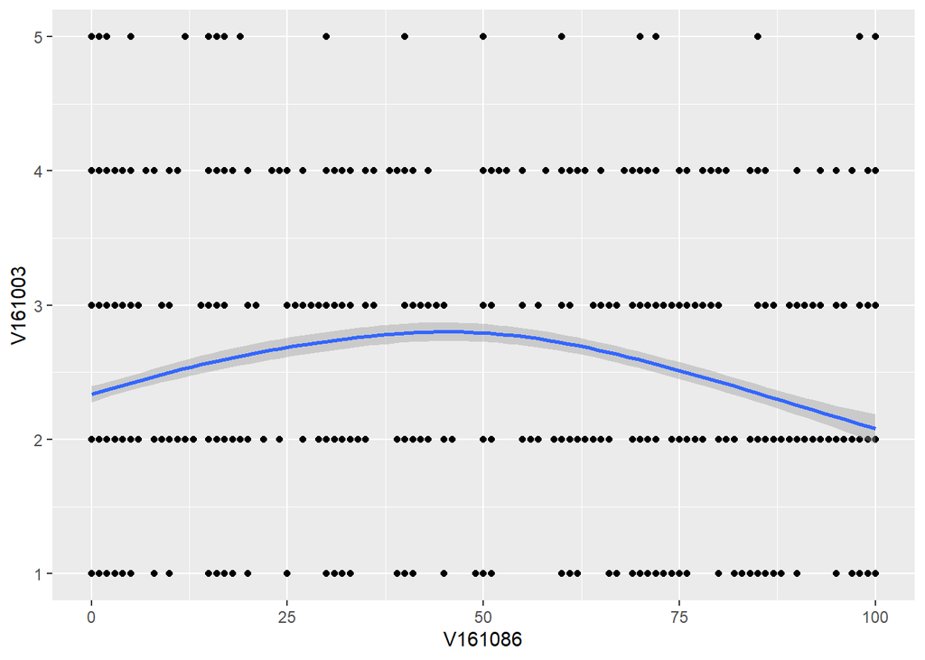

*Bonus: Add some jittering to the figure.*

## Challenge 2: “I have run the good race.”

As you are presumably aware, what with you taking this class and all: Voting for the 2020 general election is already underway. Some estimates have it that there have already been over a *million* votes cast in this election. While that may be a lot, that’s honestly a drop in the bucket. We may well see somewhere between **145–150 million** votes cast by the time this election is all said and done.

All of these votes have been by mail and/or absentee. Let’s estimate how the race is unfolding in Rowan County, North Carolina.

**Using the NC_abs_Ro.csv and ROWAN_absentee_20201103.csv files, make a bar chart that:**

**1. Compares the number of absentee requests from Republican, Democrat, and Unaffiliated voters**

**2. Compares the number of ballots *already cast* among these groups.**

Here is an example of what I’m looking for, using Union county.

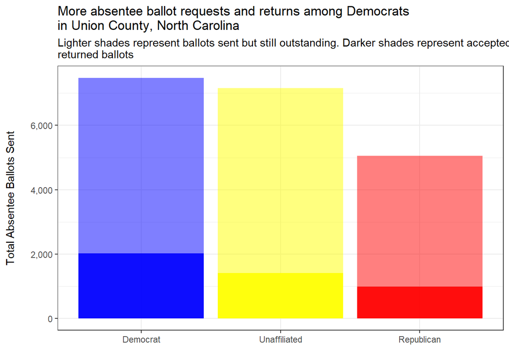

You don’t have to get all the colors and everything fancy; I just wanted to give you a clear example.

*Bonus: Replicate the color scheme seen in my example image.*

## Challenge 3: “Time after time.”

North Carolina isn’t the only state where you can glean interesting information about absentee ballots. Georgia also provides a county-by-county breakdown of the individuals who have requested a ballot. It might be interesting to chart out when people requested the ballots over time.

Using file 025.csv from GitHub (which contains data from Chatham county), I would like for you to make a line chart that plots the **cumulative** number of ballot requests over time. Make sure the axis are labelled and that the title makes sense! Here is an example using Bartow county.

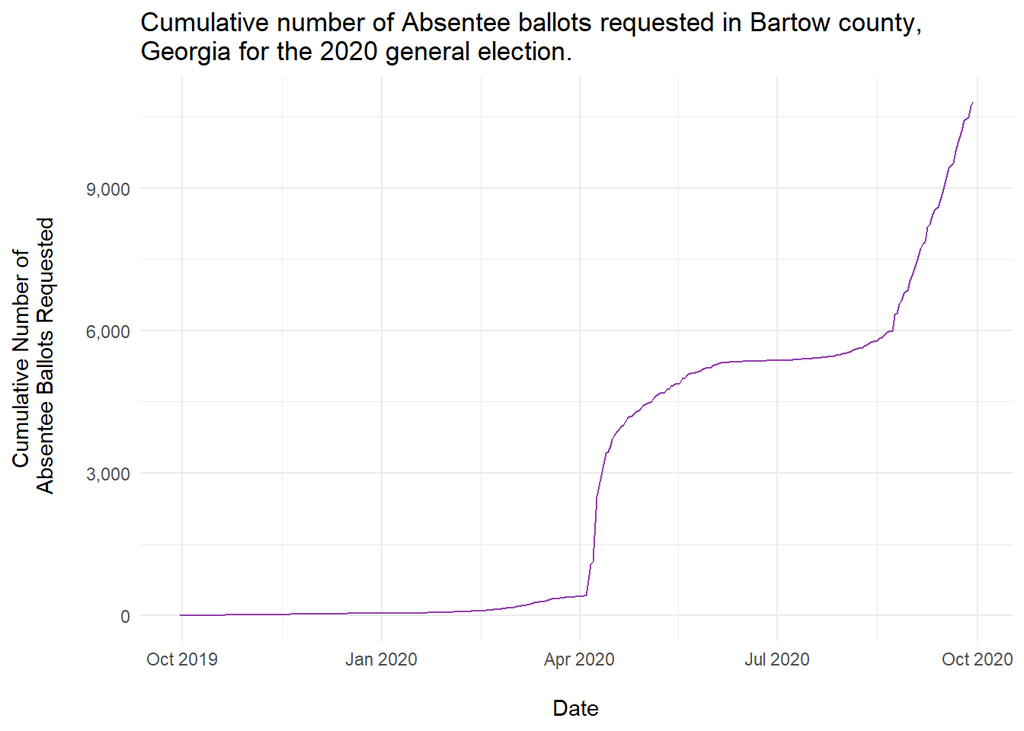

*Bonus: Change the graph’s font to Times New Roman*

## Challenge 4: The expanded universe

`ggplot` comes prepacked with a bunch of awesome geoms. However, there are times when these won’t fit—either for aesthetic or practical purposes. I would like for you to use the internet to find 2 R packages that offers additional `ggplot` geoms. Pick your favorite geom within the packages (some may have multiple geoms) and briefly explain how this could be useful for visualizing and/or exploring election data.

*That’s all for this week. Stay safe!*